# Christian Carme and Scott Marsden

#### Comparing the two matrices the Hillary matrix has a lot more activity and more correlations amoung the words. Some of the patterns have to with "company", "profit", and "share". Like Trump she says "thank", "you", and "Lester" a lot. there is also a pattern with "minimum" and "wage". Another pattern is "equal", "pay", and "women". Based on this matrix we can see a lot more patterns of speech emerging and a lot more activity in the matrix. We can identify some key topics said by Clinton which seem to be related a lot to money and energy/infrastructure in various ways.

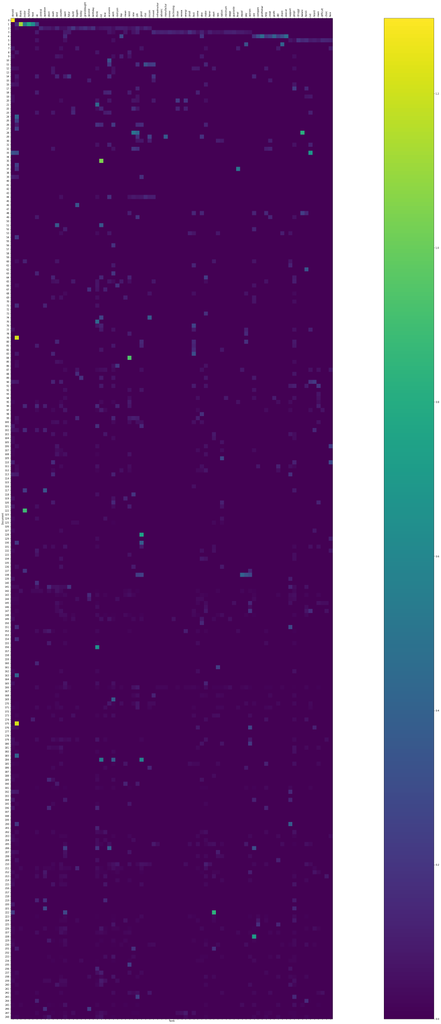

```python
width = 80
height = 80
fig = plt.figure(figsize=(width, height))
ax = fig.add_subplot(111)
cax = ax.matshow(clinton_TD[:,:80])
fig.colorbar(cax)
plt.xticks(np.arange(80), clinton_unique_terms, rotation=90)
plt.yticks(np.arange(num_clinton_docs), np.arange(num_clinton_docs))
plt.xlabel('Term')
plt.ylabel('Document')
plt.show()
```

```python
dist = pdist(clinton_TD, metric='cosine')
dist = squareform(dist)
# Convert cosine distance to similarity
# (so that bigger numbers mean more similar)
sim = 1 - dist
print(sim.shape)
sim
```

```
(249, 249)
```

```
array([[1.        , 0.        , 0.        , ..., 0.        , 0.02013325,
        0.03300432],
       [0.        , 1.        , 0.00707873, ..., 0.        , 0.01167153,
        0.00659706],
       [0.        , 0.00707873, 1.        , ..., 0.06776334, 0.08943614,
        0.08325073],
       ...,
       [0.        , 0.        , 0.06776334, ..., 1.        , 0.        ,
        0.12424602],
       [0.02013325, 0.01167153, 0.08943614, ..., 0.        , 1.        ,
        0.14391814],
       [0.03300432, 0.00659706, 0.08325073, ..., 0.12424602, 0.14391814,
        1.        ]])
```

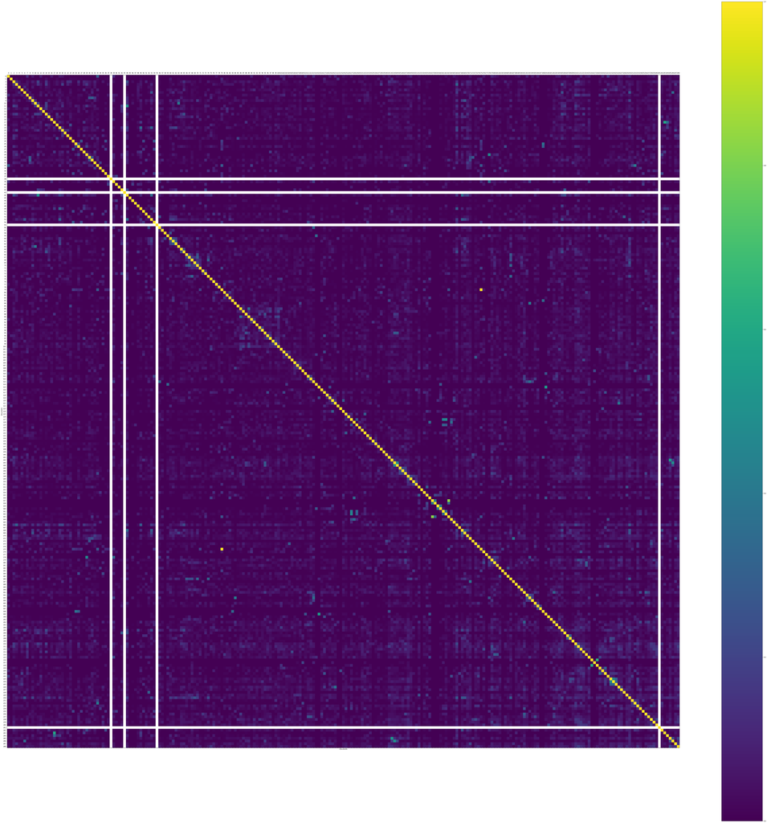

```python
fig = plt.figure(figsize=(100, 100))
ax = fig.add_subplot(111)
cax = ax.matshow(sim)
fig.colorbar(cax)
plt.xticks(np.arange(num_clinton_docs), np.arange(num_clinton_docs))
plt.yticks(np.arange(num_clinton_docs), np.arange(num_clinton_docs))
plt.xlabel('Document' )
plt.ylabel('Document')
plt.show()
```